[figure not shown]

AB(diag)-4

General Description

AIRBAG SYSTEM (DIAGNOSTICS)

3. General Description

A: CAUTION

Refer to “CAUTION” in “General Description” in Airbag System. <Ref. to AB-9, CAUTION, General Descrip-

tion.>

B: INSPECTION

Measure the battery voltage and check electrolyte.

Standard voltage: 12 V

Specific gravity: 1.260 or more

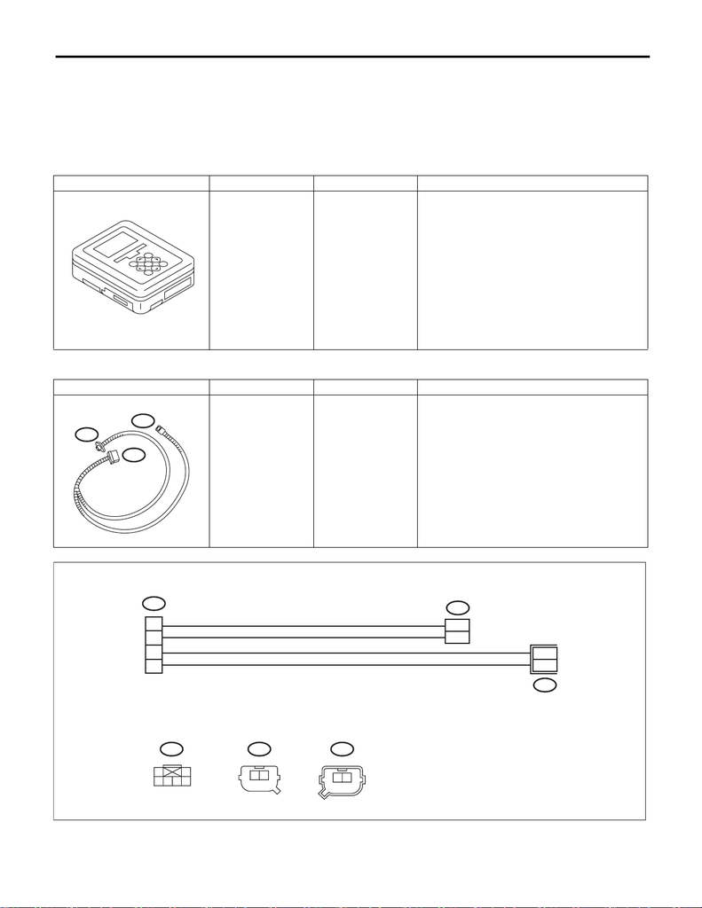

AB(diag)-5

General Description

AIRBAG SYSTEM (DIAGNOSTICS)

C: PREPARATION TOOL

CAUTION:

To measure the voltage and resistance of airbag system component, be sure to use the specified test

harness.

1. SPECIAL TOOL

• Subaru Select Monitor

• TEST HARNESS H

ILLUSTRATION TOOL NUMBER DESCRIPTION REMARKS

1B022XU0 SUBARU SELECT

MONITOR III KIT

Used for troubleshooting the electrical system.

ILLUSTRATION TOOL NUMBER DESCRIPTION REMARKS

98299FA030 TEST HARNESS H Used when measuring voltage and resistance of

front sub sensor and front door impact sensor.

ST1B022XU0

3H

2H

1H

ST98299FA030

AB-00720

3H

3H 2H 1H

2H

1H

4

3

6

5

1

3456

2

1

1

2

2

21

21

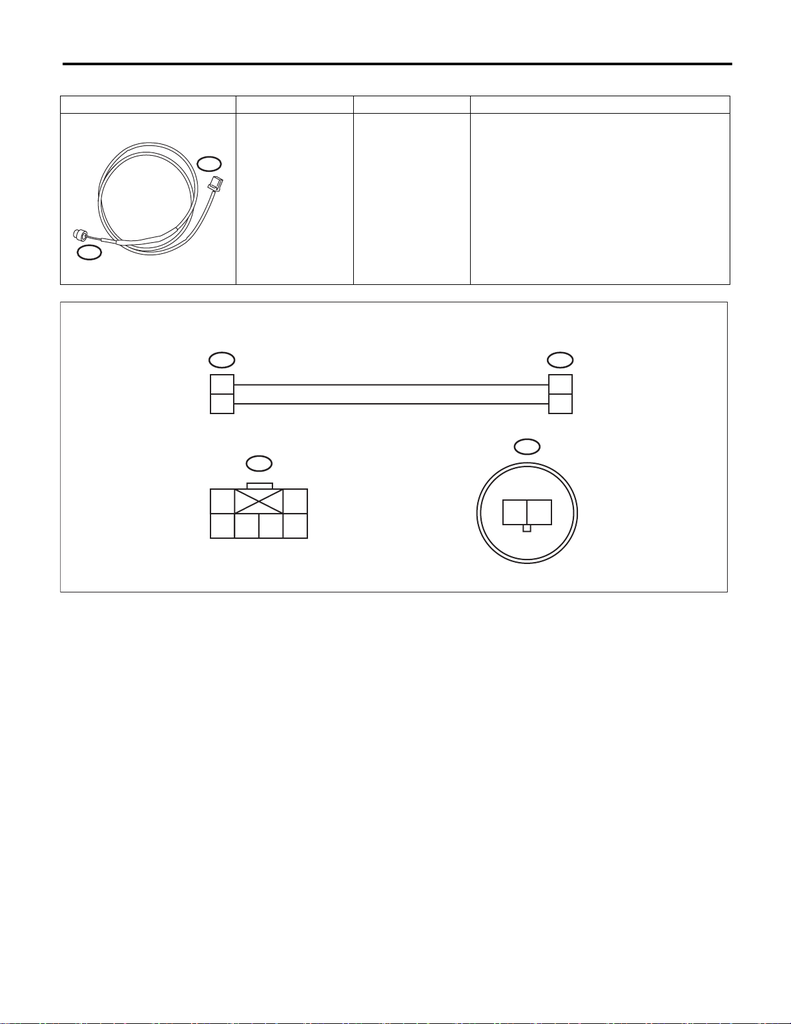

AB(diag)-6

General Description

AIRBAG SYSTEM (DIAGNOSTICS)

• TEST HARNESS N

ILLUSTRATION TOOL NUMBER DESCRIPTION REMARKS

98299SA000 TEST HARNESS N Used when measuring voltage and resistance of

driver’s airbag module, seat belt pretensioner

and curtain airbag module.

2N

1N

ST98299SA000

AB-00928

2N 1N

1

2

2

1

1

2

2

1

1N

2N

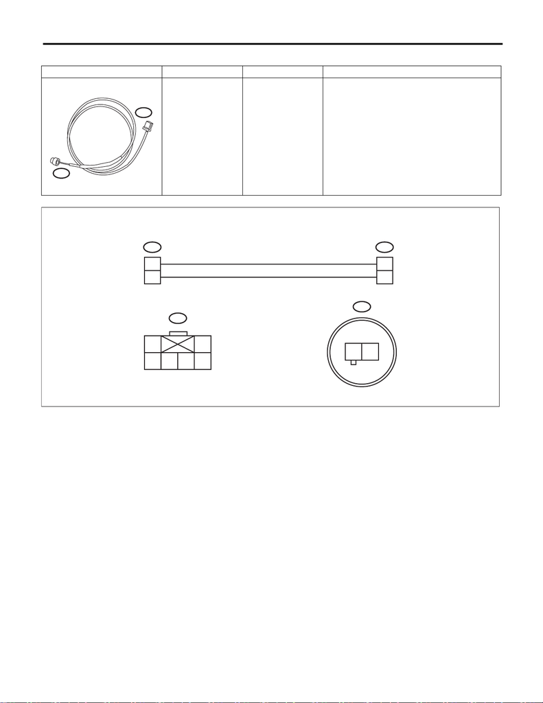

AB(diag)-7

General Description

AIRBAG SYSTEM (DIAGNOSTICS)

• TEST HARNESS Q

ILLUSTRATION TOOL NUMBER DESCRIPTION REMARKS

98299SA040 TEST HARNESS Q Used when measuring voltage and resistance of

driver’s airbag module.

2Q

1Q

ST98299SA040

AB-00929

2Q 1Q

1

2

2

1

1

2

2

1

1Q

2Q

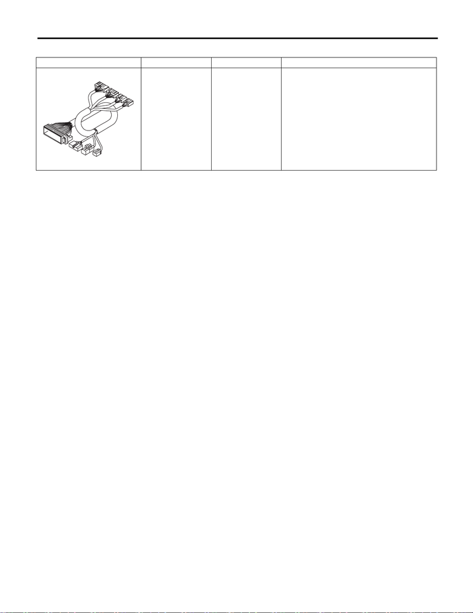

AB(diag)-8

General Description

AIRBAG SYSTEM (DIAGNOSTICS)

• TEST HARNESS AG

ILLUSTRATION TOOL NUMBER DESCRIPTION REMARKS

98299AG070 TEST HARNESS

AG

Used when measuring voltage and resistance of

airbag control module.

ST98299AG070

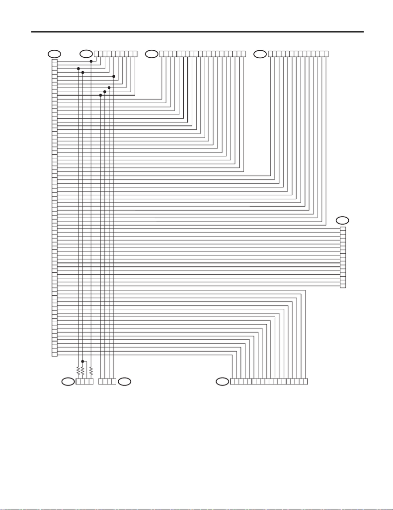

AB(diag)-9

General Description

AIRBAG SYSTEM (DIAGNOSTICS)

AB-01902

2

3

1

4

5

6

7

8

9

39

29

32

30

31

44

26

27

25

28

59

37

76

36

19

38

54

70

52

69

10

51

53

55

67

56

68

11

12

78

22

73

71

24

63

16

13

14

65

62

60

61

34

43

33

40

74

75

20

18

21

17

64

15

72

23

57

66

58

2AG

987654321

10

45

46

49

50

35

48

42

47

41

987654321

4AG

1

2

3

4

12

5

6

7

8

9

10

11

13

14

3AG

1413121110

987654321

15

16

5AG

18141312

171615

1110

9876543

21

6AG

54

32

7AG

5432

8AG

1AG

77

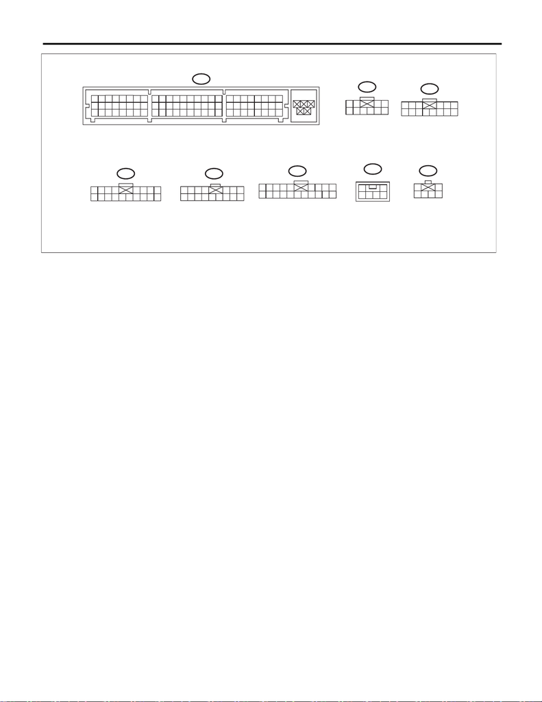

AB(diag)-10

General Description

AIRBAG SYSTEM (DIAGNOSTICS)

AB-01781

1 2 3 4

5678 9

10

2AG

1AG

12

9

141516

1718192021

22

2324

2526273334

71727374

55566162

75

767778

345678

10111213

2829303132

60 59 58 57

123

89

10

4

11 12 13 14

56

7

4AG

3AG

123

12

4

13 14 15 16 17 18

789

19

56

10 11 20

8AG

7AG

12

3456

1

3456

2

123 8

9

10

4

11 12 13 14 15 16

567

17 18

6AG 5AG

1234 5

67

8

9

10 11 12 13

14 15 16

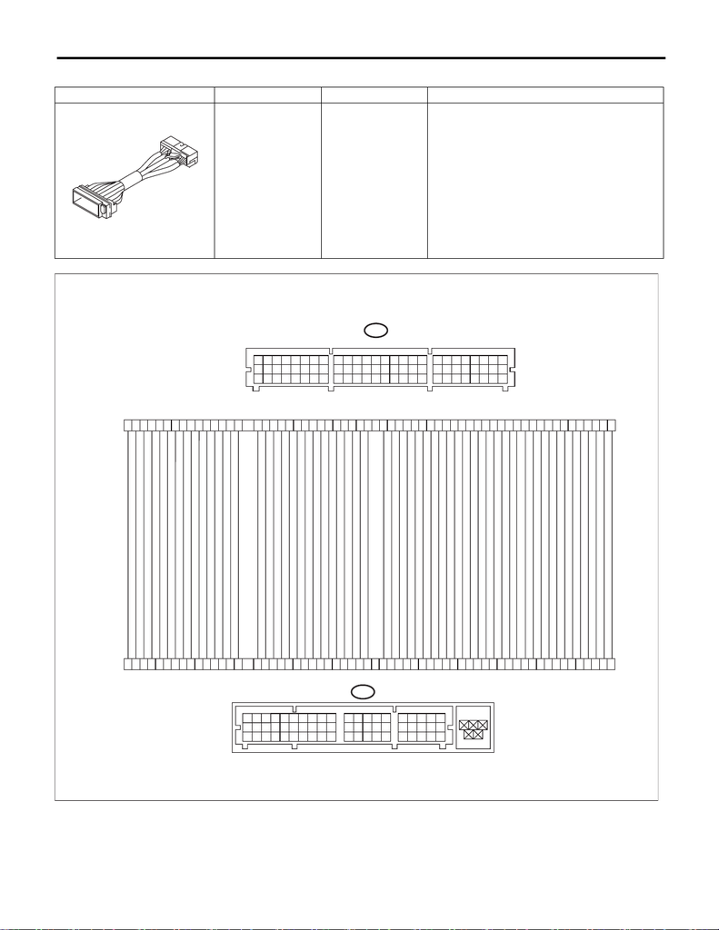

AB(diag)-11

General Description

AIRBAG SYSTEM (DIAGNOSTICS)

• TEST HARNESS AH

ILLUSTRATION TOOL NUMBER DESCRIPTION REMARKS

98299AG080 TEST HARNESS

AH

Used together with test harness AG when mea-

suring voltage and resistance of the airbag con-

trol module.

ST98299AG080

27

28

29

30

51

53

43

10

11

12

13

14

15

16

17

18

19

20

32

33

34

35

36

37

38

39

40

41

42

44

45

46

47

49

50

52

54

21

22

23

24

25

26

31

55

56

57

58

59

60

1

2

3

4

5

6

7

8

9

21

48

46

68

67

54

53

52

50

49

47

45

12

11

10

9

20

19

74

7

8

4

3

2

1

18

17

62

61

60

59

55

12

9

14 15 16

17 18 19 20 21

22

23 24

25 26 27 33 34

71 72 73 74

55 56 61 62

75

76 77 78

345678

10 11 12 13

28 29 30 31 32

60595857

69

70

76

75

56

78

77

32

30

29

28

26

25

34

33

27

36

44

43

41

40

39

38

37

35

2AH

1AH

12

50 49 48 47 46

56575859

3637

60

345

1920313233

40 39 38

9

1415

678

10

111213

48

42

51

AB-01802

31

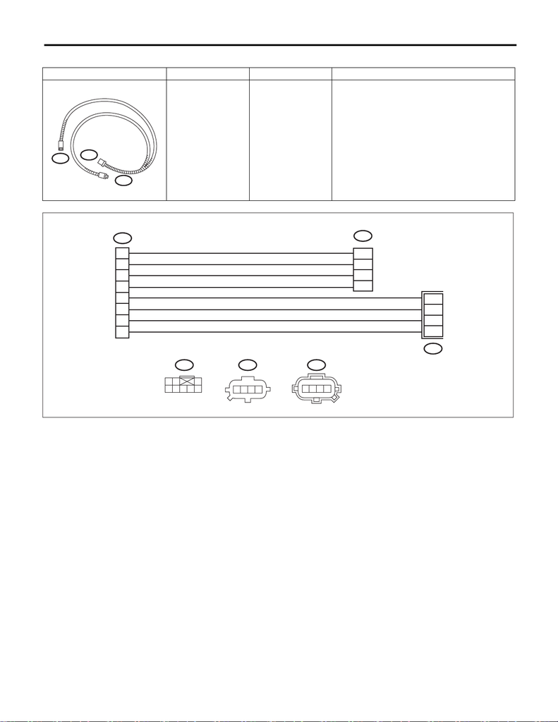

AB(diag)-12

General Description

AIRBAG SYSTEM (DIAGNOSTICS)

• TEST HARNESS V

ILLUSTRATION TOOL NUMBER DESCRIPTION REMARKS

98299AG010 TEST HARNESS V Used when measuring voltage and resistance of

side airbag sensor and curtain airbag sensor.

ST98299AG010

1V

3V

2V

AB-02282

3V

2V

1V

3V

8

5

1

4

2

3

7

6

2

1

4

3

12 3

45678

432

1

2V

123

4

1V

3

4

1

2

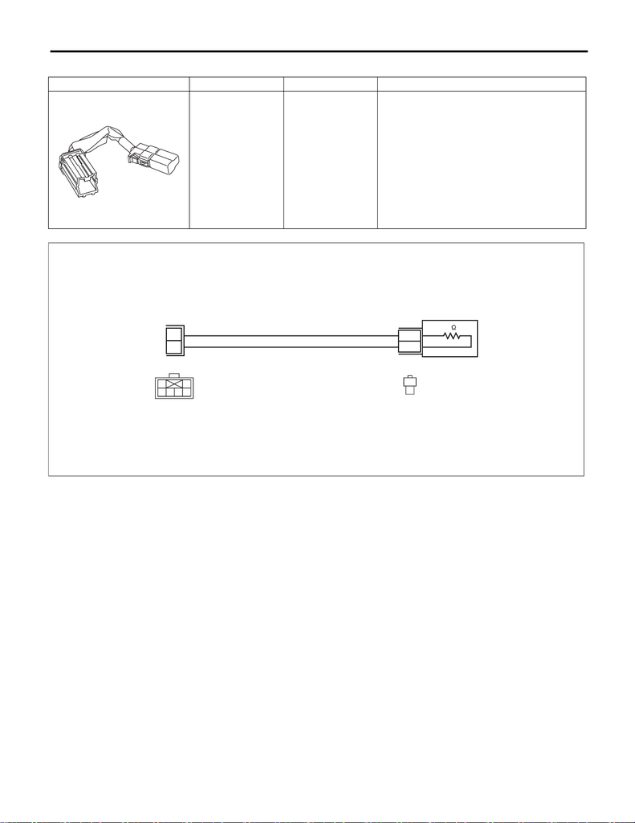

AB(diag)-13

General Description

AIRBAG SYSTEM (DIAGNOSTICS)

• AIRBAG RESISTOR

ILLUSTRATION TOOL NUMBER DESCRIPTION REMARKS

98299PA040 AIRBAG RESISTOR Used in replacement of airbag module for which

resistance value is same as airbag module.

Two ST are required for diagnosis of two-stage

inflator type airbag module.

ST98299PA040

AB-00433

3

1

2

1

2

1

2

1

3456

2

4

3

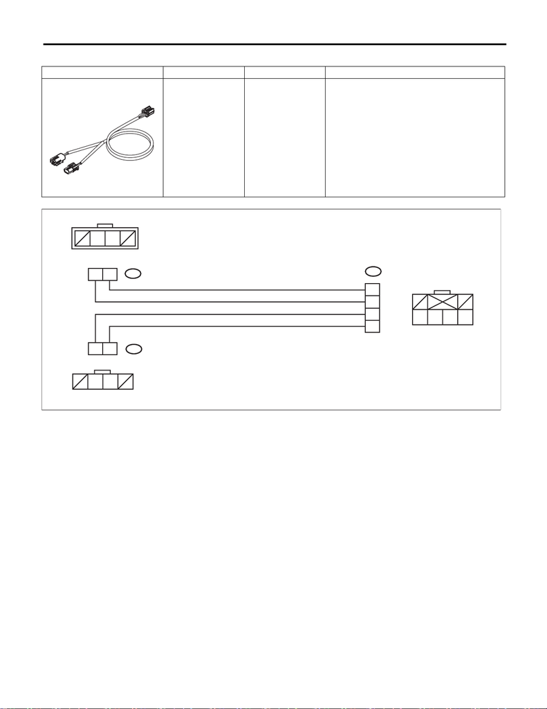

AB(diag)-14

General Description

AIRBAG SYSTEM (DIAGNOSTICS)

• TEST HARNESS AJ

ILLUSTRATION TOOL NUMBER DESCRIPTION REMARKS

98299FG000 TEST HARNESS AJ Used when measuring power supply and resis-

tance of side airbag harness.

ST98299FG000

AB-01852

3AJ

1AJ

2AJ

4

1 2

43

3

2

1

12

43

4

31

2

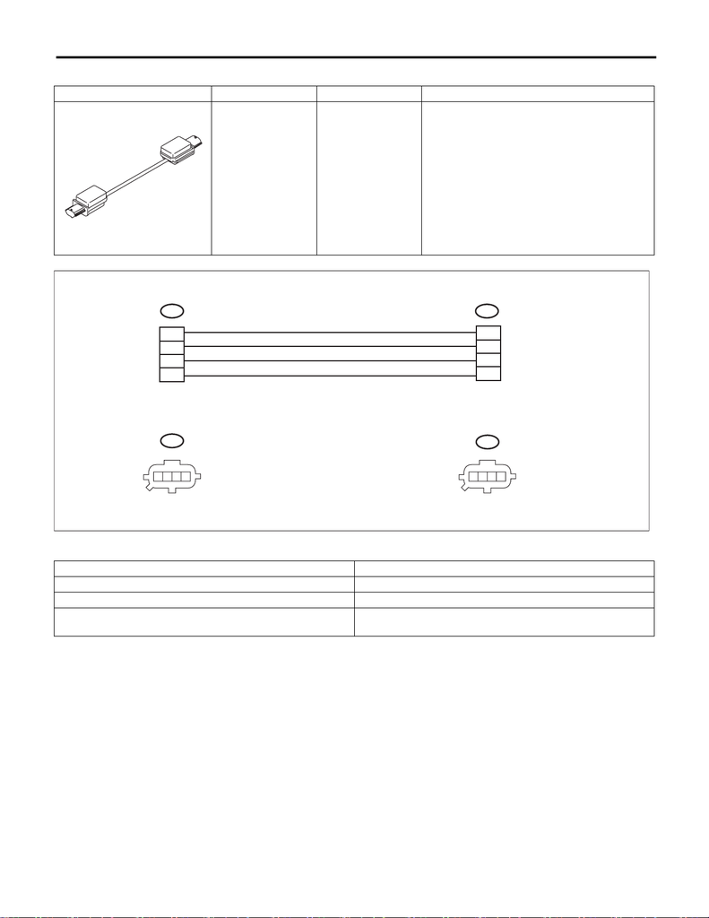

AB(diag)-15

General Description

AIRBAG SYSTEM (DIAGNOSTICS)

• TEST HARNESS AI

2. GENERAL TOOL

ILLUSTRATION TOOL NUMBER DESCRIPTION REMARKS

98299AG090 TEST HARNESS AI • Used for diagnoses of side airbag sensor and

curtain airbag sensor.

• Used together with test harness V.

TOOL NAME REMARKS

Circuit tester Used for measuring resistance, voltage and current.

Oscilloscope Used for measuring the sensor.

Probe Used when measuring voltage and resistance of passenger’s

airbag module.

ST98299AG090

AB-02283

2AI

1AI

2

1

4

3

2

1

4

3

2AI1AI

432

1

432

1

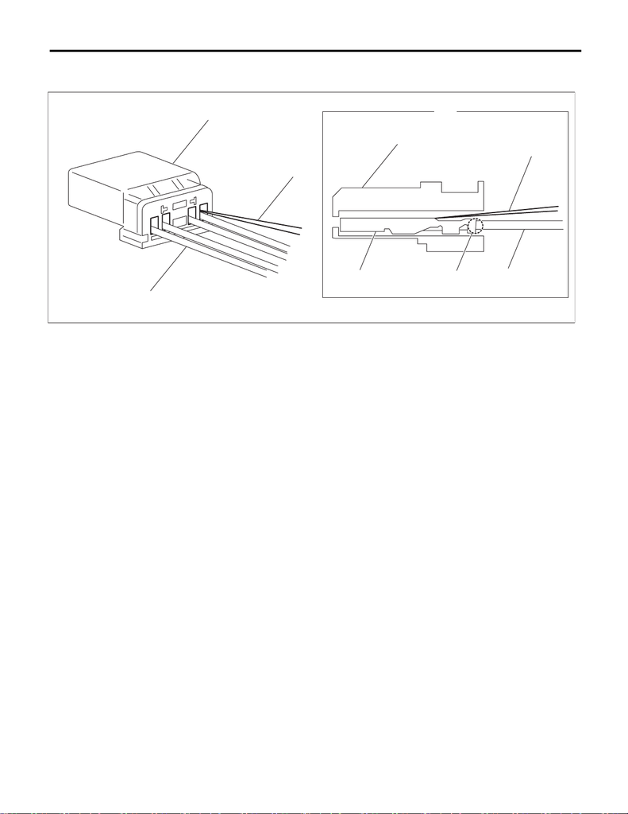

AB(diag)-16

General Description

AIRBAG SYSTEM (DIAGNOSTICS)

3. HOW TO USE PROBE

Insert the probe into the harness hole, and contact it with the terminal.

CAUTION:

• Do not insert the probe forcibly.

• Be careful not to contact it to the connection (5) between the terminal and harness. (Harness will

come off easily from connector if doing so.)

(A) Cross section

(1) Probe (3) Harness (5) Connection

(2) Connector (housing) (4) Terminal

AB-02773

(1)

(2)

(2)

(3)

(A)

(1)

(3)

(4)

(5)